# Inferencia (frecuentista)

León Berdichevsky Acosta

06 de septiembre de 2018

Estas notas están basadas en el libro [An Introduction to the Bootstrap de Effron y Tibshirani](http://www.amazon.com/Introduction-Bootstrap-Monographs-Statistics-Probability/dp/0412042312) y abordan los siguientes temas:

- Muestras aleatorias
- El principio del *plug-in*
- Bootstrap no paramétrico

## Muestras aleatorias

Supongamos que tenemos una población finita o **universo** $U$, conformado por **unidades individuales** $U_1,U_2,...,U_N$ caracterizadas por una **unidad observacional** (individuos de género masculino, etc.). Cada unidad individual tiene la misma probabilidad de ser seleccionada en una **extracción** aleatoria. Las unidades individuales $\{U_i\}$ tienen propiedades que nos gustaría aprender (opinión política, etc.). Debido a que es muy difícil o simplemente imposible examinar cada unidad en $U$ seleccionamos una muestra aleatoria.

Una **muestra aleatoria** de tamaño $n$ se define como una colección de $n$ unidades $u_1,...,u_n$ seleccionadas aleatoriamente de un universo $U$ compuesto por $N$ unidades, con $N>n$.

En principio el proceso de muestreo es como sigue:

1. Seleccionamos $n$ números enteros de manera independiente $j_1,...,j_n$ (con probabilidad $1/N$), cada uno de ellos asociado a un número entre $1$ y $N$.
2. Los enteros determinan las unidades que seleccionamos: $u_1=U_{j_1},u_2=U_{j_2},...,u_n=U_{j_n}$.

En la práctica el proceso de selección suele ser más complicado y la definición de la población $U$ suele ser deficiente; sin embargo, el marco conceptual sigue siendo útil para entender la inferencia estadística.

En específico, el proceso de muestreo descrito anteriormente es equivalente a una serie de $n$ repeticiones independientes de un experimento aleatorio (o ensayos) en los que cada unidad seleccionada corresponde a un resultado (*output*) posible de cada experimento, y el espacio de resultados está dado por el universo $U$. Ésto nos permite interpretar las **frecuencias observadas** de las unidad individuales en la muestra utilizando la definición frecuentista de probabilidad: en términos de frecuencias relativas.

Observación: Nuestra definición de muestra aleatoria permite que una unidad particular $U_i$ aparezca más de una vez, podríamos evitar esto si realizamos un **muestreo sin remplazo**; sin embargo, es un poco más sencillo permitir repeticiones y si el tamaño de la muestra $n$ es mucho más pequeño que la población $N$, la probabilidad de muestrear la misma unidad más de una vez es pequña.

Una vez que se selecciona una muestra aleatoria $u_1,...,u_n$ obtenemos una o más **medidas** de interés $x_i$ (o **características**, o **variables**) para cada unidad $u_i$. Cada medida está descrita por una variable aleatoria. Por lo que el conjunto de medidas $x_i$ para cada unidad $u_i$ corresponde a un conjunto de valores, uno por cada variables aleatorias.

Los **datos observados** son la colección de medidas $x_1,...,x_n$, que también denotaremos $\textbf{x} = (x_1,...,x_n)$, asociados a la muestra aleatoria.

También podemos obtener las medidas de interés de cada unidad en la población $U_1,U_2,...,U_N$, obteniendo así los valores $X_1,...,X_N$; esto sería un **censo**, y denotamos al conjunto de mediciones de la población por $\mathcal{X}$.

El objetivo de la **inferencia estadística** es expresar lo que hemos aprendido de la población $\mathcal{X}$ a partir de los datos observados $\textbf{x}$.

La **Estadística Inferencial** es la rama de la Estadística que se ocupa de la inferencia estadística. Se divide en dos grandes subareas:

1. **Estimación** (puntual y por intervalos).
2. **Pruebas de Hipótesis**.

En este curso consideraremos únicamente el problema de Estimación. En particular, vamos a usar el **bootstrap** para determinar la precisión con la que un **estadístico** (ej., media, mediana) calculada de la muestra $x_1,...,x_n$ estima la cantidad correspondiente en la población.

**Ejemplo:** Veamos un ejemplo artificial en el cual tomaremos una muestra del universo completo de escuelas primarias de la Ciudad de México:

```r
load("data/base_completa.Rdata")
prim <- tbl_df(primaria) %>%
    filter(entidad == "DISTRITO FEDERAL", !is.na(esp.3), !is.na(esp.6)) %>%
    select(clave, turno, tipo = tipo.esc, mun = clave.mun, esp3 = esp.3,
        esp6 = esp.6) %>%
    mutate(tipo = as.character(tipo))
```

La población consta de 3311 escuelas. Tomamos una muestra de 500 escuelas:

```r
set.seed(16021)
n <- 500
prim_muestra <- sample_n(prim, n, replace = TRUE)
glimpse(prim_muestra)
```

```
#> Observations: 500
#> Variables: 6
#> $ clave <fct> 09DPR3043G, 09PPR1369C, 09DBN0026X, 09DPR2982T, 09DPR290...
#> $ turno <fct> MATUTINO, MATUTINO, NOCTURNO, VESPERTINO, MATUTINO, MATU...
#> $ tipo  <chr> "GENERAL", "PARTICULAR", "GENERAL", "GENERAL", "GENERAL"...
#> $ mun   <int> 16, 18, 26, 16, 26, 18, 25, 16, 13, 16, 26, 20, 16, 13, ...
#> $ esp3  <dbl> 539, 670, 630, 536, 539, 543, 689, 587, 579, 627, 615, 5...
#> $ esp6  <dbl> 543, 592, 0, 563, 588, 618, 711, 567, 557, 545, 608, 558...
```

Para cada escuela en la muestra tenemos dos medidas $x_i$, dadas por el promedio de las calificaciones en español de los alumnos de tercero y sexto de primaria (prueba ENLACE 2010):
$$x_i=(esp3_i, esp6_i)$$

## El principio del *plug-in*

En este contexto, podemos reformular la definición de distribución empírica en términos de la muestra aleatoria.

Dada una muestra aleatoria de tamaño $n$ de una distribución de probabilidad $P$, la función de **distribución empírica** $P_n$ se define como la distribución que asigna probabilidad $1/n$ a cada valor $x_i$ con $i=1,2,..., n$. En otras palabras, $P_n$ asigna a un conjunto $A$ en el espacio muestral de $x$ la probabilidad empírica:

$$P_n(A)=\#\{x_i \in A \}/n$$

Muchos problemas de inferencia estadística involucran la estimación de alguna característica de una distribución de probabilidad $P$ en base a una muestra aleatoria obtenida de $P$. La función de distribución empírica $P_n$ es una estimación de la distribución completa $P$, por lo que una manera inmediata de estimar alguna característica de $P$ (ej., media, mediana) es calcular la característica correspondiente de $P_n$.

**Ejemplo:** Podemos comparar el histograma de la distribución completa con el histograma de la distribución empírica para el ejemplo de las calificaciones de la prueba ENLACE.

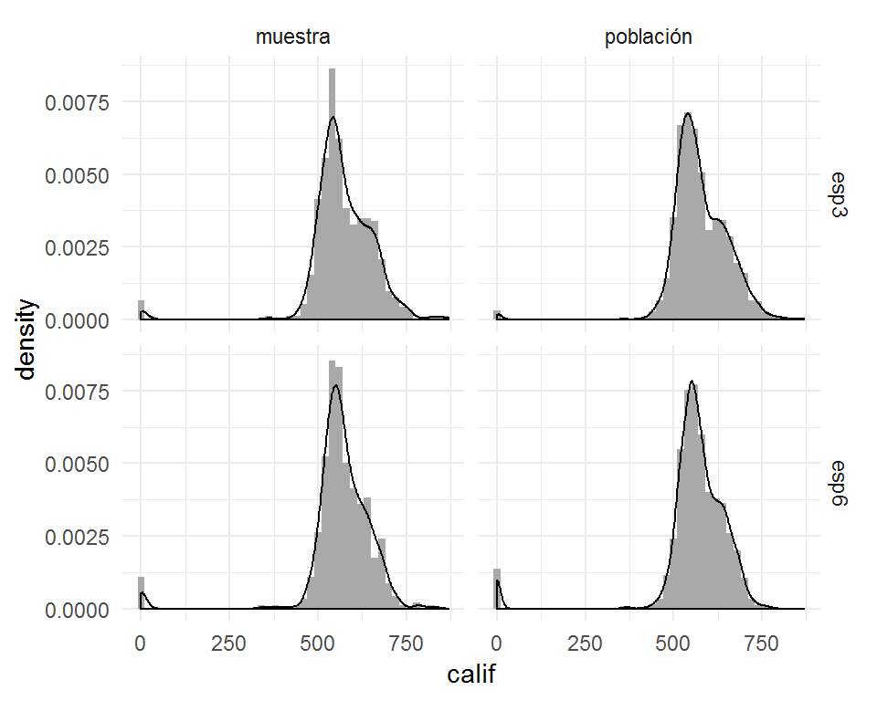

```r
claves_muestra <- prim_muestra$clave
prim_long <- prim %>%
    gather(grado, calif, esp3, esp6) %>%
    mutate(muestra = ifelse(clave %in% claves_muestra, "muestra", "población"))

ggplot(prim_long, aes(x = calif)) +
  geom_histogram(aes(y = ..density..), binwidth = 20, fill = "darkgray") +
  geom_density() +
  facet_grid(grado ~ muestra)
```

Cuando la variable de interés toma pocos valores es fácil interpretar la distribución empírica. Supongamos que la medición de las unidades que nos interesa es la variable `tipo` de escuela, entonces la distribución empírica de esta variable calculada de la muestra en cuesión es:

```r
table(prim_muestra$tipo) / n
```

```
#>
#>    GENERAL PARTICULAR
#>      0.654      0.346
```

Vale la pena notar que cuando la variable toma valores discretos, pasar de la muestra desagregada a la distribución empírica (lista de valores y la proporción que ocurre cada uno de ellos en la muestra) no conlleva ninguna pérdida de información: el **vector de frecuencias observadas** $P_n(\textbf{x}):= (P_n(x_1),...,P_n(x_n))$ es un **estadístico suficiente** para la verdadera distribución. Esto quiere decir que toda la información de $P$ contenida en el vector de observaciones $\textbf{x}$ está también contenida en la distribución empírica $P_n$.

**Nota**: El **teorema de suficiencia** asume que las observaciones $\textbf{x}$ son una muestra aleatoria de la distribución $P$, este no es siempre el caso, como por ejemplo si se trata de una serie de tiempo.

**Ejemplo: 100 lanzamientos de un dado.** En este ejemplo obtenemos la siguiente distribución empírica:

```r
dado <- read.table("../05. Repaso de Probabilidad/data/dado.csv", header=TRUE, quote="\"")
n <- length(dado$observado)
n
```

```
#> [1] 100
```

```r
table(dado$observado) / n
```

```
#>
#>    1    2    3    4    5    6
#> 0.13 0.19 0.10 0.17 0.14 0.27
```

En este caso no tenemos un censo, solo contamos con la muestra.

Cuando aplicamos teoría estadística a problemas reales, es común que las respuestas estén dadas en términos de distribuciones de probabilidad. Para resolver este tipo de preguntas, debemos hacer inferencia a partir de la distribución empírica.

**Ejemplo:** Una pregunta de inferencia que surge de manera natural en este ejemplo es si el dado es justo, esto es, si la distribución que generó esta muestra tiene una distribución $P = (1/6, 1/6, 1/6,1/6, 1/6, 1/6)$.

**Ejemplo:** Podemos preguntarnos qué tan correlacionados están los resultados de las pruebas de español correspondientes a tercero y sexto grados. Si conocemos la distribución de probabilidad conjunta $P$ de estas dos variables aleatorias, la respuesta a esta pregunta es simplemente cuestión de aritmética: el **coeficiente de correlación poblacional** esta dado por:

$$corr(y,z) = \frac{\sum_{j=1}^{N}(Y_j - \mu_y)(Z_j-\mu_z)P_i}
{[\sum_{j=1}^{N}(Y_j - \mu_y)^2P_i \sum_{j=1}^{N}(Z_j - \mu_z)^2P_i]^{1/2}}$$

donde el punto $(Y_j,Z_j)$ son las medidas de la j-ésima unidad de la población de escuelas primarias $\mathcal{X}$, mientras que $\mu_y=\sum Y_j/3311$ y $\mu_z=\sum Z_j/3311$ son las medias poblacionales y $P_j$ es la probabilidad asociada.

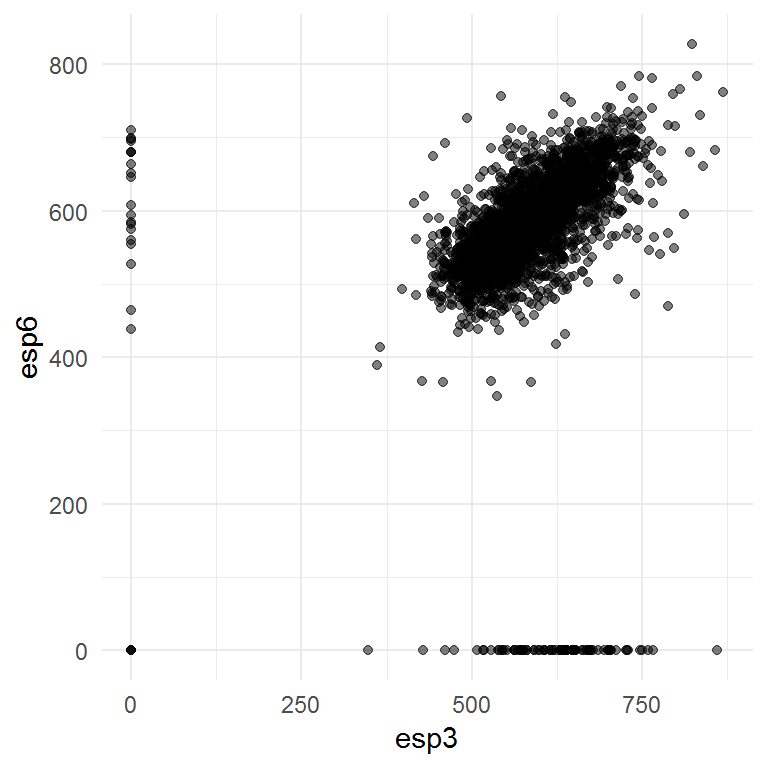

```r
ggplot(prim, aes(x = esp3, y = esp6)) +
  geom_point(alpha = 0.5)
```

```r
cor(prim$esp3, prim$esp6)
```

```
#> [1] 0.24
```

Si no tenemos un censo debemos inferir. Podríamos estimar la correlación $corr(y,z)$ a través del coeficiente de correlación muestral:
$$\hat{corr}(y,z) = \frac{\sum_{j=1}^{n}(y_j - \hat{\mu}_y)(z_j-\hat{\mu}_z)}
{[\sum_{j=1}^{n}(y_j - \hat{\mu}_y)^2\sum_{j=1}^{n}(z_j - \hat{\mu}_z)^2]^{1/2}}$$

```r
cor(prim_muestra$esp3, prim_muestra$esp6)
```

```
#> [1] 0.28
```

o cualquier otro **estimador**.

La idea del **Principio del *plug-in*** es realizar estimaciones utilizando únicamente los datos de la muestra; esto es, sin hacer ninguna suposición acerca de la distribución de probabilidad $P$.

Antes de proseguir con la definición exacta, repasemos dos conceptos importantes: parámetros y estadísticos:

Un **parámetro** es una función de la distribución de probabilidad $\theta=t(P)$. Un **estadístico** es una función de la muestra $\hat{\theta}=s(\textbf{x})$ y por tanto es una variable aleatoria con una distribución $Q$ inducida por $P$ y denominada **distribución muestral**. Un **estimador** es un **estadístico** utilizado para estimar un **parámetro**.

Por ejemplo, la $corr(x,y)$ es un parámetro de $P$ y $\hat{corr}(x,y)$ es un estadístico con base en $\textbf{x}$ y $\textbf{y}$.

Entonces:

El **principio del *plug-in*** es un método para estimar parámetros a partir de muestras; la estimación *plug-in* de un parámetro $\theta=t(P)$ se define como:
$$\hat{\theta}=t(P_n).$$

Es decir, estimamos la función $\theta = t(P)$ de la distribución de probabilidad $P$ utilizando la misma función pero aplicada a la distribución empírica $\hat{\theta}=t(P_n)$.

**Ejemplos de estimaciones *plug-in*:**

- El estimador $\hat{corr}(y,z)$ del ejemplo de las escuelas es un estimador *plug-in*.
- Estimación *plug-in* de la mediana de las calificaciones de español para tercero de primaria:

```r
median(prim_muestra$esp3)
```

```
#> [1] 562
```

- Estimación de la probabilidad $\theta$ de que la calificación de español de una escuela sea mayor a 700:

$$\theta=\frac{1}{N}\sum_{j=1}^N I_{\{Y_i>700\}}$$

donde $I_{\{\cdot\}} \in \{0,1\}$ es la función indicadora.

Hacemos la estimación *plug-in* $\hat{\theta}$:

```r
sum(prim_muestra$esp3 > 700) / n
```

[output not shown]

El principio del *plug-in* provee de una estimación puntual de un parámetro, más no contiene información acerca de la **precisión** de la estimación.

### Estimadores del error estándar

Los estadísticos como $\hat{\theta}=t(P_n)$ suelen ser el primer paso en el análisis de datos, el siguiente paso es investigar la precisión de las estimaciones. El error estándar es la manera más común para describir la precisión de un estadístico:

El **error estándar** es la estimación de la desviación estándar de un estadístico.

#### Estimación *plug-in* del error estándar

**Ejemplo: El error estándar de una media.** Supongamos que $X$ es una variable aleatoria que toma valores en los reales $\Omega_X = \mathbb{R}$ y con distribución de probabilidad $P$. Denotamos por $\mu_P$ y $\sigma_P^2$ la media y varianza de $P$,

$$E_P(X)=\mu_P,$$
$$var_P(X)=E_P[(X-\mu_P)^2]=\sigma_P^2$$

en la notación enfatizamos la dependencia de la media y varianza en la distribución $P$.

Ahora, sea $\textbf{x}=(x_1,...,x_n)$ una muestra aleatoria de $P$, de tamaño $n$. La media de la muestra es $\bar{x}=\sum_{i=1}^nx_i/n$, el cual es el estimador *plug-in* de $\mu_P$.

La distribución $P$ de $X$ induce una distribución desconocida $Q$ de $\bar{x}$. Se puede desmostrar que el estadístico $\bar{x}$ tiene esperanza y varianza

$$E_Q[\bar{x}]=\mu_P$$
,

$$var_Q(\bar{x})=\sigma_P^2/n$$
en la notación enfatizamos la dependencia de la media y varianza en la distribución $Q$, inducida por la distribución $P$.

En palabras: la esperanza de $\bar{x}$ es la misma que la esperanza de $X$, pero la varianza de $\bar{x}$ es $1/n$ veces la varianza de $X$, así que entre mayor es la $n$ tenemos una mejor estimación de $\mu_P$ dada por $\bar{x}$.

Para calcular la precisión con la que $\bar{x}$ estima $\mu_P$ calculamos el error estándar, que denotamos por $se_Q(\bar{x})$, el cual es la raíz de la varianza de $\bar{x}$,
$$se_Q(\bar{x}) = [var_Q(\bar{x})]^{1/2}= \sigma_P/ \sqrt{n}.$$

En este punto podemos usar el principio del *plug-in* para estimar $\sigma_P$, simplemente sustituimos $P_n$ por $P$ y obtenemos una estimación de $\sigma_P$:
$$\hat{\sigma}=\sigma_{P_n} = \bigg\{\frac{1}{n}\sum_{i=1}^n(x_i-\bar{x})^2\bigg\}^{1/2}=\sqrt{var_{P_n}(X)}$$

por lo que la estimación *plug_in* del error estándar de $\bar{x}$ es:
$$\hat{se}(\bar{x})=se_{P_n}(\bar{x})=\sigma_{P_n}/\sqrt{n}=\bigg\{\frac{1}{n^2}\sum_{i=1}^n(x_i-\bar{x})^2\bigg\}^{1/2}$$
en la notación de la primera igualdad enfatizamos que la estimación *plug-in* de un parámetro de la distribución inducida $Q$ se puede calcular a partir de la muestra $\textbf{x}$; esto es, depende de la distribución empírica $P_n$ de $P$.

Notemos que usamos el principio del *plug-in* en dos ocasiones:

1. Primero para estimar la esperanza $\mu_P$ mediante $\bar{x}=\mu_{P_n}$.
2. Posteriormente para estimar el error estándar $se_Q(\bar{x})$ mediante $se_{P_n}(\bar{x})$.

En términos generales, esperamos que $\bar{x}$ este a una distancia de $\mu_P$ menor a un error estándar el 68% del tiempo, y a menos de 2 errores estándar el 95% del tiempo. Estos porcentajes están basados el teorema central del límite que nos dice que bajo ciertas condiciones (bastante generales) de $P$ la distribución de $\bar{x}$ se aproximará a una distribución normal:
$$\bar{x} \sim Q \approx N(\mu_P,\sigma_P^2/n), \quad n\gg 1$$
En el caso de la media $\hat{\theta}=\bar{x}$, la aplicación del principio del *plug-in* para el cálculo de errores estándar es inmediata; sin embargo, hay estadísticos para los cuáles no es fácil o es imposible calcular de manera exacta el estimador *plug-in* y es en estas situaciones cuando recurrimos técnicas computacionales.

## Bootstrap no paramétrico

La técnica **bootstrap** es un algoritmo computacional basado en remuestreo para aproximar con precisión arbitraria el estimador *plug-in* del error estándar de un estadístico.

### El estimador bootstrap del error estándar

Supongamos que tenemos una muestra aleatoria $\textbf{x}=(x_1,x_2,...,x_n)$ proveniente de una distribución de probabilidad desconocida $P$ y deseamos estimar un parámetro $\theta = t(P)$ con base en la muestra. Para esto, calculamos una estimación $\hat{\theta}=s(\textbf{x})$ (la estimación puede ser la estimación *plug-in* $\hat{\theta}=t(P_n)$ pero también puede ser otra). Entonces podemos utilizar bootstrap para calcular el error estándar de la estimación.

Definimos una **muestra bootstrap** como una muestra aleatoria de tamaño $n$ que se obtiene de la distribución empírica $P_n$ y la denotamos
$$\textbf{x}^* = (x_1^*,...,x_n^*).$$

La notación de estrella indica que $\textbf{x}^*$ no son los datos $\textbf{x}$ sino una versión de **remuestreo** de $\textbf{x}$.

Otra manera de frasearlo: Los datos bootstrap $x_1^*,...,x_n^*$ son una muestra aleatoria de tamaño $n$ seleccionada con reemplazo de la población de $n$ objetos $(x_1,...,x_n)$ con distribución $P_n$..

Ahora, a cada muestra bootstrap $\textbf{x}^*$ le corresponde una **replicación** $\hat{\theta}^*=s(\textbf{x}^*).$

La fórmula del estimador *plug-in* del error estándar de un estadístico $\hat{\theta}$ es $se_{P_n}(\hat{\theta})$ y no existe para casi ninguna estimación diferente a la media, por lo que recurrimos a la técnica computacional bootstrap: el algoritmo funciona seleccionando distintas muestras bootstrap, evaluando la replicación bootstrap correspondiente y estimando el error estándar de $\hat{\theta}$ mediante la desviación estándar empírica de las replicaciones. El resultado es la **estimación bootstrap del error estándar**, que denotamos $\hat{se}_B$, donde $B$ es el número de muestras bootstrap utilizadas.

#### Algoritmo bootstrap para estimar errores estándar

1. Selecciona $B$ muestras bootstrap independientes:
   $$\textbf{x}^{*1},..., \textbf{x}^{*B}$$
   .
2. Evalúa la replicación bootstrap correspondiente a cada muestra bootstrap:
   $$\hat{\theta}^*(b)=s(\textbf{x}^{*b}), \quad b=1,2,...,B$$
3. Estima el error estándar $se_P(\hat{\theta})$ usando la desviación estándar muestral de las $B$ replicaciones:
   $$\hat{se}_B = \bigg\{\frac{\sum_{b=1}^B[\hat{\theta}^{*}(b)-\hat{\theta}^*(\cdot)]^2 }{B-1}\bigg\}^{1/2}$$

donde
$$\hat{\theta}^*(\cdot)=\sum_{b=1}^B \hat{\theta}^{*}(b)/B$$
es la media muestral de las replicaciones $\{\hat{\theta}^{*}\}$.

Conforme el número de replicaciones $B$ aumenta el estimador bootstrap del error estándar se aproxima al estimador *plug-in* del error estándar:
$$\hat{se}_B\approx se_{P_n}(\hat{\theta}), \quad B\gg1$$
Este hecho equivale a decir que la desviación estándar empírica se acerca a la desviación estándar poblacional de $P_n$ conforme crece el número de muestras $B$.

Al estimador bootstrap $\hat{se}_B$ y al estimador *plug-in* $se_{P_n}(\hat{\theta})$ se les denomina estimadores no paramétricos ya que estan basados en $P_n$, el estimador no paramétrico de la distribución poblacional $P$.

**Ejemplo:** Escribimos una función para estimar el error estándar de la media de la calificación de la prueba de español de tercer grado de escuelas primarias de la Ciudad de México utilizando la muestra que consideramos antes.

Calculamos primero el estimador bootstrap del error estándar:

```r
mediaBoot <- function(x){
  # x: muestra
  # n: tamaño de la muestra
  n <- length(x)
  muestra_boot <- sample(x, size = n, replace = TRUE) # Una remuestra
  mean(muestra_boot) # Replicacion bootstrap de theta_gorro
}
# Consideramos B=500 replicaciones
set.seed(8372683)
thetas_boot <- rerun(500, mediaBoot(prim_muestra$esp3)) %>% flatten_dbl()
sd(thetas_boot)
```

```
#> [1] 4.17
```

Y lo comparamos el estimador *plug-in* del error estándar:

```r
se <- function(x) sqrt(sum((x - mean(x)) ^ 2)) / length(x)
se(prim_muestra$esp3)
```

```
#> [1] 4.14
```

**Nota:** Conforme $B$ aumenta tenemos que $\hat{se}_{B}(\bar{x})\to \{\sum_{i=1}^n(x_i - \bar{x})^2 / n \}^{1/2}$, lo cual se demuestra con la ley débil de los grandes números.

##### ¿Cuántas replicaciones bootstrap $B$?

La estimación bootstrap ideal es un resultado asintótico $B=\infty$, en el que $\hat{se}_B$ converge a la estimación *plug-in* $se_{P_n}(\hat{\theta})$. En la práctica, para elegir el tamaño de $B$, debemos considerar el hecho de que deseamos las mismas propiedades para la estimación de un error esrándar que para cualquier estimación: poco sesgo y desviación estándar chica. El sesgo de la estimación bootstrap del error estándar suele ser bajo.

Reglas de dedo (Effron y Tibshirani):

1. Incluso un número chico de replicaciones bootstrap, digamos $B=25$ es informativo, y $B=50$ con frecuencia es suficiente para dar una buena estimación de $se_{P_n}(\hat{\theta})$.
2. En pocos casos es necesario realizar más de $B=200$ replicaciones cuando se busca estimar **error estándar**.

**Ejemplo:** Consideremos varios valores para el número de replicaciones $B$ y las estimaciones bootstrap del error estándar de la media de las calificaciones de la prueba de español de tercer grado correspondientes:

```r
seMediaBoot <- function(x, B){
    thetas_boot <- rerun(B, mediaBoot(x)) %>% flatten_dbl()
    sd(thetas_boot)
}

B_muestras <- data_frame(n_sims = c(5, 25, 50, 100, 200, 400, 1000, 1500, 3000)) %>%
    mutate(est = map_dbl(n_sims, ~seMediaBoot(x = prim_muestra$esp3, B = .)))
B_muestras
```

```
#> # A tibble: 9 x 2
#>   n_sims   est
#>    <dbl> <dbl>
#> 1      5  2.61
#> 2     25  4.52
#> 3     50  4.61
#> 4    100  4.20
#> 5    200  4.21
#> 6    400  4.42
#> 7   1000  4.01
#> 8   1500  4.20
#> 9   3000  4.17
```

**Ejemplo: Componentes principales: calificaciones en exámenes.** Los datos *marks* (Mardia, Kent y Bibby, 1979) contienen una muestra que consiste en los puntajes de 88 estudiantes en 5 pruebas: mecánica, vectores, álgebra, análisis y estadística. Cada renglón corresponde a la calificación de un estudiante en cada prueba.

```r
marks <- read_csv("data/marks.csv")
glimpse(marks)
```

```
#> Observations: 88
#> Variables: 6
#> $ id   <int> 1, 2, 3, 4, 5, 6, 7, 8, 9, 10, 11, 12, 13, 14, 15, 16, 17...
#> $ MECH <int> 77, 63, 75, 55, 63, 53, 51, 59, 62, 64, 52, 55, 50, 65, 3...
#> $ VECT <int> 82, 78, 73, 72, 63, 61, 67, 70, 60, 72, 64, 67, 50, 63, 5...
#> $ ALG  <int> 67, 80, 71, 63, 65, 72, 65, 68, 58, 60, 60, 59, 64, 58, 6...
#> $ ANL  <int> 67, 70, 66, 70, 70, 64, 65, 62, 62, 62, 63, 62, 55, 56, 5...
#> $ STAT <int> 81, 81, 81, 68, 63, 73, 68, 56, 70, 45, 54, 44, 63, 37, 7...
```

```r
marks <- select(marks, -id)
head(marks)
```

```
#> # A tibble: 6 x 5
#>    MECH  VECT   ALG   ANL  STAT
#>   <int> <int> <int> <int> <int>
#> 1    77    82    67    67    81
#> 2    63    78    80    70    81
#> 3    75    73    71    66    81
#> 4    55    72    63    70    68
#> 5    63    63    65    70    63
#> 6    53    61    72    64    73
```

La muestra $\textbf{x}$ es una base de datos de $88 \times 5$, y donde $i$-ésima fila corresponde a al conjunto de medidas $x_i$ de la unidad $u_i$.

Un análisis de componentes principales sería como sigue:

```r
pc_marks <- princomp(marks)
summary(pc_marks)
```

```
#> Importance of components:
#>                        Comp.1 Comp.2  Comp.3 Comp.4 Comp.5
#> Standard deviation     26.061 14.136 10.1276 9.1471  5.638
#> Proportion of Variance  0.619  0.182  0.0935 0.0763  0.029
#> Cumulative Proportion   0.619  0.801  0.8948 0.9710  1.000
```

```r
loadings(pc_marks)
```

```
#>
#> Loadings:
#>      Comp.1 Comp.2 Comp.3 Comp.4 Comp.5
#> MECH  0.505  0.749  0.300  0.296
#> VECT  0.368  0.207 -0.416 -0.783  0.189
#> ALG   0.346        -0.145        -0.924
#> ANL   0.451 -0.301 -0.597  0.518  0.286
#> STAT  0.535 -0.548  0.600 -0.176  0.151
#>
#>                Comp.1 Comp.2 Comp.3 Comp.4 Comp.5
#> SS loadings       1.0    1.0    1.0    1.0    1.0
#> Proportion Var    0.2    0.2    0.2    0.2    0.2
#> Cumulative Var    0.2    0.4    0.6    0.8    1.0
```

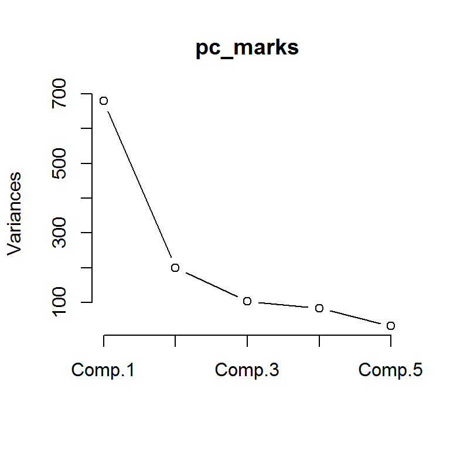

```r
plot(pc_marks, type = "lines")
```

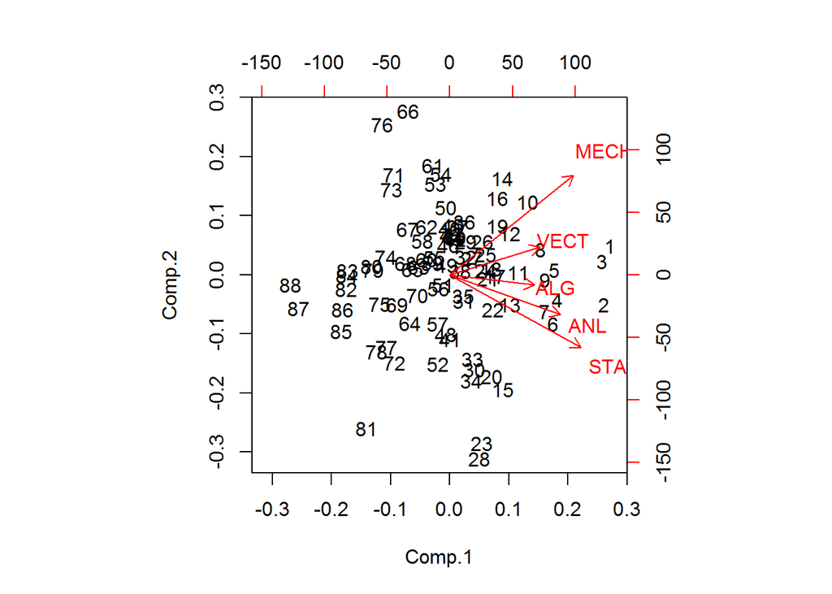

```r
biplot(pc_marks)
```

Los cálculos de un análisis de componentes principales involucran la matriz de covarianzas empírica $G$ (estimaciones *plug-in*)

$$G_{jk} = \frac{1}{88}\sum_{i=1}^88(x_{ij}-\bar{x_j})(x_{ik}-\bar{x_k})$$

para $j,k=1,2,3,4,5$, y donde $\bar{x_j} = \sum_{i=1}^88 x_{ij} / 88$ (la media de la $i$-ésima columna). La matriz de covarianzas empírica es:

```r
G <- cov(marks) * 87 / 88
G
```

```
#>      MECH  VECT   ALG   ANL  STAT
#> MECH  302 125.8 100.4 105.1 116.1
#> VECT  126 170.9  84.2  93.6  97.9
#> ALG   100  84.2 111.6 110.8 120.5
#> ANL   105  93.6 110.8 217.9 153.8
#> STAT  116  97.9 120.5 153.8 294.4
```

Los **pesos** $\hat{\lambda}_i$ y las **componentes principales** $\hat{\nu}_i$ estimadas son los valores y vectores propios de la matriz de covarianzas $G$; estos se calculan a través de una serie de de manipulaciones algebraicas que requieren cálculos del orden de $p^3$ (cuando $G$ es una matriz de tamaño $p\times p$):

```r
eigen_G <- eigen(G)
lambda <- eigen_G$values
v <- eigen_G$vectors
lambda
```

```
#> [1] 679.2 199.8 102.6  83.7  31.8
```

```r
v
```

```
#>        [,1]    [,2]   [,3]     [,4]    [,5]
#> [1,] -0.505  0.7487  0.300  0.29618 -0.0794
#> [2,] -0.368  0.2074 -0.416 -0.78289 -0.1889
#> [3,] -0.346 -0.0759 -0.145 -0.00324  0.9239
#> [4,] -0.451 -0.3009 -0.597  0.51814 -0.2855
#> [5,] -0.535 -0.5478  0.600 -0.17573 -0.1512
```

Nos interesa estimar el parámetro
$$\theta=\frac{\lambda_1}{\sum_{i=1}^5\lambda_i}$$
el cual mide el porcentaje de la varianza explicada por la primer componente principal $\nu_1$. También deseamos cuantificar la estimación mediante el error estándar del estimador .

La estimación *plug-in* es
$$\hat{\theta}=\frac{\hat{\lambda}_1}{\sum_{i=1}^5\hat{\lambda}_i}$$
y está dada por:

```r
theta_hat <- lambda[1]/sum(lambda)
theta_hat
```

```
#> [1] 0.619
```

¿Qué tan preciso es $\hat{\theta}$? Para calcular el error estándar de $\hat{\theta}$ tenemos que poder calcular una réplica $\hat{\theta}^*$ para una muestra bootstrap $\textbf{x}^*$; en esta caso una muestra bootstrap es una base de datos de $88 \times 5$.

```r
pc_boot <- function(){
    muestra_boot <- sample_n(marks, size = 88, replace = TRUE)
    G <- cov(muestra_boot) * 87 / 88
    eigen_G <- eigen(G)
    theta_hat <- eigen_G$values[1] / sum(eigen_G$values)
}
# Consideramos B=1000 replicaciones
B <- 1000
thetas_boot <- rerun(B, pc_boot()) %>% flatten_dbl()
```

Veamos un histograma de las replicaciones de $\hat{\theta}$:

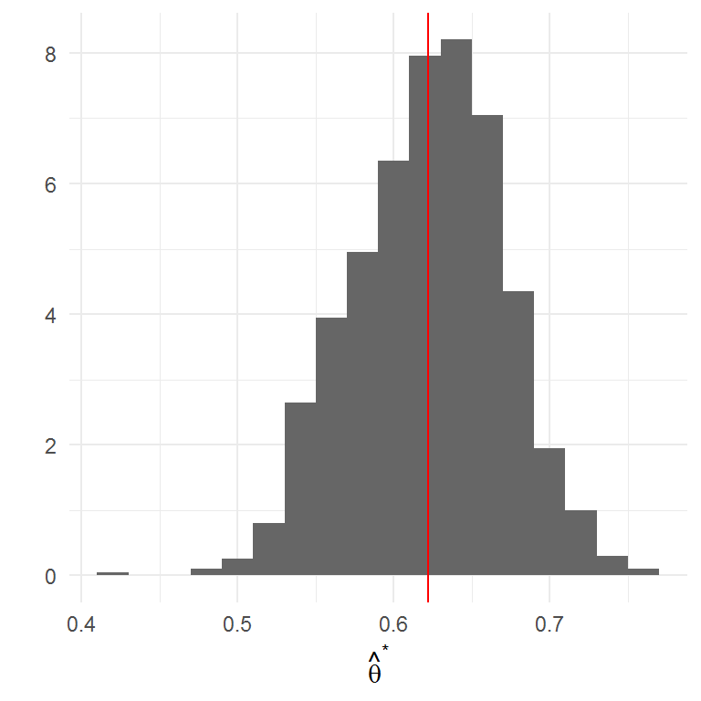

```r
ggplot(data_frame(theta = thetas_boot)) +
    geom_histogram(aes(x = theta, y = ..density..), binwidth = 0.02, fill = "gray40") +
    geom_vline(aes(xintercept = mean(theta)), color = "red") +
    labs(x = expression(hat(theta)^"*"), y = "")
```

Podemos calcular la media

```r
mean(thetas_boot)
```

```
#> [1] 0.622
```

y la desviación estándar, la cual nos da la estimación bootstrap del error estándar de $\hat{\theta}$:

```r
theta_se <- sd(thetas_boot)
theta_se
```

```
#> [1] 0.0477
```

**Ejercicio 2:** Las componentes principales estimadas $\hat{v}_i$ son estadísticos. El vector propio estimado $\hat{v}_1$ corresponde al mayor valor propio estimado $\hat{\lambda}_1$ y se conoce como primera componente de $G$. Usa bootstrap para dar una medición de su variabilidad.

### Otras estructuras de datos

Introdujimos el bootstrap en el contexto de muestras aleatorias, esto es, suponiendo que las observaciones son independientes; en este escenario basta con aproximar la distribución desconocida $P$ usando la distribución empírica $P_n$, y el cálculo de los estadísticos es inmediato. Hay casos en los que el mecanismo que generó los datos es más complicado, por ejemplo, cuando tenemos dos muestras, en diseños de encuestas complejas o en series de tiempo.

#### Dos muestras

Podemos pensar en algún modelo probabilístico $P$ como compuesto por dos poblaciones con distribuciones de probabilidad independientes $G$ y $Q$. En este caso, las observaciones de cada grupo provienen de distribuciones distintas y el método bootstrap debe tomar en cuenta esto al generar las muestras bootstrap.

**Ejemplo.** Se realiza un experimento en el que se seleccionan 7 ratones de manera aleatoria de un total de 16 ratones. A los siete seleccionados se les suministra un tratamiento mientras que los restantes formarán el grupo de control. El objetivo del tratamiento es prolongar la supervivencia de los ratones. La siguiente tabla muestra el tiempo de supervivencia en días después de suministrar el tratamiento a los ratones del grupo de tratamiento y un placebo a los ratones del grupo de control.

| Grupo | Datos | Tamaño de muestra |
| --- | --- | --- |
| Tratamiento | 94, 197, 16, 38, 99, 141, 23 | 7 |
| Control | 52, 104, 146, 10, 51, 30, 40, 27, 46 | 9 |

En este caso podemos pensar en la población del grupo de tratamiento y en la población del grupo de control como independientes.

**Ejercicio 3:** Determine si el tratamiento prolongó la supervivencia de los ratones que recibieron el tratamiento siguiendo los siguientes pasos:

1. Usa las medias de las muestras para determinar si hay diferencias en los grupos; esto es, calcula $\bar{x}-\bar{y}$.
2. Estima el error estándar de la diferencia usando bootstrap.
3. Corrobora tus resultados del punto anterior usando que $\hat{se}(\bar{x}-\bar{y})=\sqrt{\hat{se}(\bar{x})^2 + \hat{se}(\bar{y})^2}$
4. ¿Dirías que el tratamiento incrementó la supervivencia de los ratones que recibieron el tratamiento?
5. Supongamos que deseamos comparar los grupos usando las medianas en lugar de las medias:
   1. Estima la diferencia de las medias.
   2. Usa bootstrap para estimar el error estándar de la diferencia.
   3. ¿Cuál es tu conclusión de los resultados?

#### Estructuras de datos complejas

La necesidad de estimaciones confiables junto con el uso eficiente de recursos conllevan a diseños de muestras complejas. Estos diseños típicamente usan las siguientes técnicas: muestreo sin reemplazo de una población finita, muestreo sistemático, estratificación, conglomerados, ajustes a no-respuesta, postestratificación. Como consecuencia, los valores de la muestra suelen no ser independientes.

**Ejemplo: Muestreo de encuestas.** La complejidad de los diseños de encuestas conlleva a que el cálculo de errores estándar sea muy complicado, para atacar este problema hay dos técnicas básicas:

1. un enfoque analítico usando linearización,
2. Métodos de remuestreo como bootstrap.

El incremento en el poder de cómputo ha favorecido los métodos de remuestreo pues la linearización requiere del desarrollo de una fórmula para cada estimación y supuestos adicionales para simplificar.

Un ejemplo se puede encontrar en el siguiente artículo de 1988 de [Rao y Wu](http://amstat.tandfonline.com/doi/abs/10.1080/01621459.1988.10478591#.VBjm8y5dV8w), en donde los autores propusieron un método de bootstrap para diseños estratificados multietápicos con reemplazo de Unidades Primarias de Muestreo (UPM).

### Intervalos de Confianza

Hasta ahora hemos discutido la idea detrás del bootstrap y como se puede usar para estimar el error estándar de un estadístico $\hat{\theta}$. Sin embargo, es difícil interpretar los errores estándar en términos del parámetro a estimar $\theta$.

Los errores estándar suelen usarse para construir intervalos de confianza.

Un **intervalo de confianza** es un tipo de estimación por intervalos calculado a partir del estadístico $\hat{\theta}$ y tiene asociado un **nivel de confianza** o **coeficiente de confianza** $\gamma = 1-2\alpha$ con $\gamma \in (0,1)$. Una vez especificado el nivel de confianza $\gamma$, el intervalo de confianza del parámetro $\theta$ es un intervalo con dos extremos aleatorios (dependen de la muestra) $(\theta_{\alpha}(P_n),\theta_{1-\alpha}(P_n))$ tal que:

$$P\{\theta_{\alpha} < \theta < \theta_{1-\alpha}\} = \gamma$$
esto es, la probabilidad de que el intervalo de confianza calculado con la muestra contenga al verdadero valor del parámetro $\theta$ es $\gamma$.

Usualmente, como veremos en un momento, para el cálculo de intervalos de confianza se asume que el estadístico $\hat{\theta}$ tiene una distribución normal. Sin embargo, ya que el bootstrap se puede usar para estimar la función de distribución de $\hat{\theta}$, no es necesario hacer supuestos distribucionales para $\hat{\theta}$; podemos estimar la distribución como parte del proceso de construir intervalos de confianza.

Para estudiar métodos de construcción de intervalos de confianza usaremos el siguiente ejemplo:

**Ejemplo:** supongamos que queremos estimar la asimetría de una base de datos que consta de 799 tiempos de espera entre pulsasiones de un nervio (Cox, Lewis 1976). El estimador *plug-in* de la asimetría es:

$$\hat{\theta} = t(P_n) =\frac{1/n \sum_{i=1}^n(x_i-\hat{\mu})^3}{\hat{\sigma}^3}$$

```r
nerve <- read_delim("data/nerve.txt", "\t", escape_double = FALSE,
    col_names = FALSE, trim_ws = TRUE)
nerve_long <- tidyr::gather(nerve, col, val, X1:X6) %>%
    filter(!is.na(val))

skewness <- function(x){
    n <- length(x)
    1 / n * sum((x - mean(x)) ^ 3) / sd(x) ^ 3
}
# Calculamos el estadístico
theta_hat <- skewness(nerve_long$val)
theta_hat
```

```
#> [1] 1.76
```

```r
# Creamos una muestre bootstrap y calculamos una réplica del estadístico
skewness_boot <- function(x, n){
  x_boot <- sample(x, n, replace = TRUE)
  skewness(x_boot)
}
# Calculamos B=2,000 réplicas
B <- 2000
skewness <- rerun(B, skewness_boot(nerve_long$val, length(nerve_long$val))) %>%
  flatten_dbl()
# El estimador bootstrap del error estándar de la asimetría es
sd(skewness)
```

```
#> [1] 0.165
```

1. El **Intervalo Normal** o **Intervalo Estándar**: Si el estadístico $\hat{\theta}$ tiene una distribución normal estándar, entonces el intervalo de confianza con un nivel de confianza de $\gamma = 1-2\alpha$ es

$$(\theta_{\alpha},\theta_{1-\alpha})=(\hat{\theta}- z^{(1-\alpha)}\cdot se_Q(\hat{\theta}), \hat{\theta}-z^{(\alpha)}\cdot se_Q(\hat{\theta}))$$
donde $z^{(1-\alpha)}=-z^{(\alpha)}$ es el cuantil de orden $1-\alpha$ de la distribución Normal estándar. Si $\hat{\theta}$ no tiene una distribución normal estándar pero su distribución se puede aproximar por una distribución normal estándar entonces el intervalo normal es una aproximación al intervalo de confianza.

Ya que desconocemos la distribución de probabilidad $Q$ del estadístico $\hat{\theta}$, el intervalo de confianza normal se aproxima mediante:
$$(\hat{\theta}- z^{(1-\alpha)}\cdot se_Q(\hat{\theta}), \hat{\theta}-z^{(\alpha)}\cdot se_Q(\hat{\theta})) \approx (\hat{\theta}- z^{(1-\alpha)}\cdot \hat{se}(\hat{\theta}), \hat{\theta}-z^{(\alpha)}\cdot \hat{se}(\hat{\theta}))$$

Si elejimos un nivel de confianza del $95%$ obtenemos los siguientes extremos del intervalo:

```r
li_normal <- round(theta_hat - 1.96 * sd(skewness), 2)
li_normal
ls_normal <- round(theta_hat + 1.96 * sd(skewness), 2)
ls_normal
```

```
#> [1] 1.44
#> [1] 2.08
```

Veamos un histograma de las replicaciones bootstrap de $\hat{\theta}*$

```r
nerve_skewness <- data_frame(skewness)
hist_nerve <- ggplot(nerve_skewness, aes(x = skewness)) +
        geom_histogram(binwidth = 0.05, fill = "gray30") +
            geom_vline(xintercept = c(li_normal, ls_normal, theta_hat),
            color = c("black", "black", "red"), alpha = 0.5)
```

Podemos hacer una prueba gráfica de normalidad.

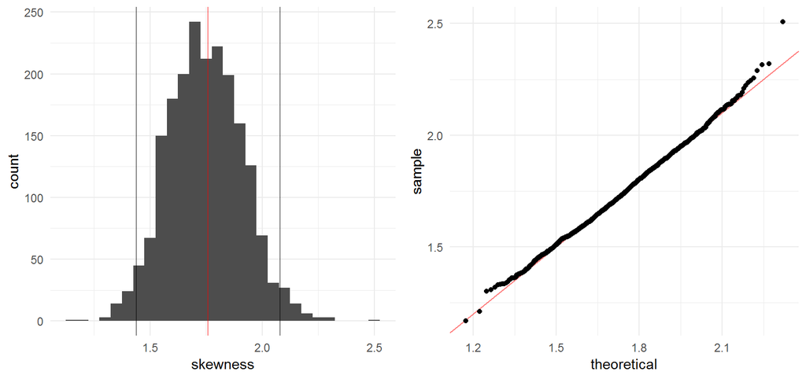

```r
qq_nerve <- ggplot(nerve_skewness) +
  geom_abline(color = "red", alpha = 0.5) +
  stat_qq(aes(sample = skewness), dparams = list(mean = mean(skewness), sd = sd(skewness)))

grid.arrange(hist_nerve, qq_nerve, ncol = 2, newpage = FALSE)
```

Vemos que el supuesto de normalidad parece razonable.

Veamos como se comparan los cuantiles de la estimación de la distribución de $\hat{\theta}$ con los cuantiles de una normal:

```r
comma(q_kurt <- quantile(skewness, probs = c(0.025, 0.05, 0.1, 0.9, 0.95, 0.975)))
comma(qnorm(p = c(0.025, 0.05, 0.1, 0.9, 0.95, 0.975), mean = theta_hat,
  sd = sd(skewness)))
```

```
#>  2.5%    5%   10%   90%   95% 97.5%
#> "1.4" "1.5" "1.5" "2.0" "2.0" "2.1"
#> [1] "1.4" "1.5" "1.5" "2.0" "2.0" "2.1"
```

Este intervalo no es preciso cuando $\hat{\theta}$ no se distribuye aproximadamente Normal. Por lo que el último análisis sugiere usar los cuantiles del histograma bootstrap para definir los límites de los intervalos de confianza:

2. **Intervalo Percentil**: Sea $Q$ la distribución de probabilida de $\hat{\theta}$ y denotemos por $G$ la función de distribución acumulada. El intervalo percentil de $1-2\alpha$ se define por los percentiles $\alpha$ y $1-\alpha$ de $G$:
   $$(\theta_{\alpha},\theta_{1-\alpha}) = (G^{-1}(\alpha), G^{-1}(1-\alpha))$$
   La distribución bootstrap es la distribución empírica de $Q$. Por lo tanto, podemos aproximar $G$ por la distribución acumulada bootstrap $G^{-1}(\alpha) \approx \hat{\theta}_B^*(\alpha)$, esto es, el percentil $100\cdot \alpha$ de la distribución bootstrap, por lo que podemos aproximar el intervalo percentil mediante el intervalo bootstrap:
   $$(G^{-1}(\alpha), G^{-1}(1-\alpha))\approx(\hat{\theta}_B^*(\alpha),\hat{\theta}_B^*(1-\alpha))$$
   En la situación bootstrap *ideal*, donde el número de replicaciones bootstrap $B$ es infinito, el intrvalo bootstrap converge al intervalo percentil.

El algoritmo para la aproximación bootstrap del intervalo percentil es:

- Generamos B muestras bootstrap independientes $\textbf{x}^{*1},..., \textbf{x}^{*B}$ y calculamos las replicaciones $\hat{\theta}^{*b}=s(x^{*b}).$
- Sea $\hat{\theta}^{*}_B(\alpha)$ el percentil $100\cdot\alpha$ de la distribución empírica de $\hat{\theta}$, y sea $\hat{\theta}^{*}_B(1-\alpha)$ el correspondiente percentil $100\cdot (1-\alpha)$, escribimos el intervalo de confianza con $1-2\alpha$ como
  $$(\theta_{\alpha},\theta_{1-\alpha})\approx(\hat{\theta}^*_B(\alpha),\hat{\theta}^*_B(1-\alpha))$$

**Ejemplo:** En nuestro ejemplo de la asimetría, los cuantiles muestrales son:

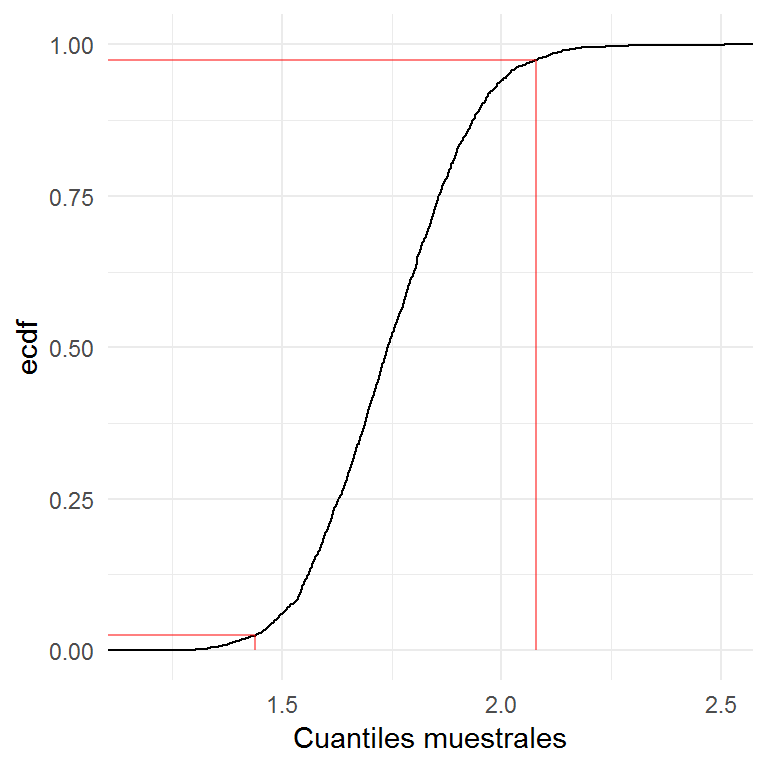

```r
ggplot(arrange(nerve_skewness, skewness)) +
    stat_ecdf(aes(x = skewness)) +
    geom_segment(data = data_frame(x = c(-Inf, -Inf, q_kurt[c(1, 6)]),
        xend = q_kurt[c(1, 6, 1, 6)], y = c(0.025, 0.975, 0, 0),
        yend = c(0.025, 0.975, 0.025, 0.975)), aes(x = x, xend = xend, y = y,
        yend = yend), color = "red", size = 0.4, alpha = 0.5) +
  labs(x = "Cuantiles muestrales", y = "ecdf")
```

Los extremos del intervalo bootstrap son:

```r
ls_per <- round(quantile(skewness, prob = 0.975), 2)
li_per <- round(quantile(skewness, prob = 0.025), 2)
stringr::str_c(li_normal, ls_normal, sep = ",")
stringr::str_c(li_per, ls_per, sep = ",")
```

```
#> [1] "1.44,2.08"
#> [1] "1.44,2.08"
```

Si la distribución de $\hat{\theta}$ es aproximadamente normal, entonces los intervalos normales y de percentiles serán similares. El teorema del límite central nos dice que conforme el tamaño de la muestra $n$ se acerca a infinito el histograma bootstrap adquirirá una forma similar a la normal; sin embargo, cuando el tamaño de muestra es chico habrá diferencias.

**Ejemplo:** Con el fin de comparar los intervalos normal y percentil creamos un ejemplo de simulación (ejemplo tomado de Effron y Tibshirani), generamos una muestra de tamaño 10 de una distribución normal estándar.

Supongamos que el parámetro de interés es $\theta=e^{\mu}$ donde $\mu$ es la media poblacional.

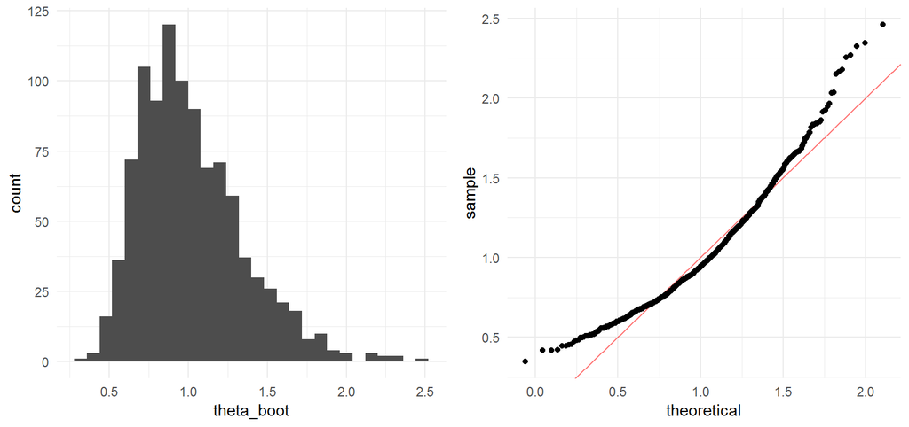

```r
set.seed(137612)
# Muestra de una distribución normal estándar de tamaña n=10
x <- rnorm(10)
# Creamos una muestra bootstrap y calculamos la replicación
boot_sim_exp <- function(){
  x_boot <- sample(x, size = 10, replace = TRUE)
  exp(mean(x_boot))
}
# Consideramos B=1,000 replicaciones
theta_boot <- rerun(1000, boot_sim_exp()) %>% flatten_dbl()
theta_boot_df <- data_frame(theta_boot)
# Creamos el histograma boostrap (replicaciones)
hist_emu <- ggplot(theta_boot_df, aes(x = theta_boot)) +
    geom_histogram(fill = "gray30", binwidth = 0.08)
# Hacemos la prueba gráfica de normalidad QQ
qq_emu <- ggplot(theta_boot_df) +
    geom_abline(color = "red", alpha = 0.5) +
    stat_qq(aes(sample = theta_boot),
        dparams = list(mean = mean(theta_boot), sd = sd(theta_boot)))

grid.arrange(hist_emu, qq_emu, ncol = 2, newpage = FALSE)
```

La distribución empírica de $\hat{\theta}^*$ es asimétrica, por lo que no esperamos que coincidan los intervalos.

```r
# Normal
round(exp(mean(x)) - 1.96 * sd(theta_boot), 2)
```

```
#> [1] 0.33
```

```r
round(exp(mean(x)) + 1.96 * sd(theta_boot), 2)
```

```
#> [1] 1.62
```

```r
#Percentil
round(quantile(theta_boot, prob = 0.025), 2)
```

```
#> 2.5%
#> 0.54
```

```r
round(quantile(theta_boot, prob = 0.975), 2)
```

```
#> 97.5%
#>  1.78
```

La inspección del histograma deja claro que la aproximación normal no es conveniente en este caso, veamos que ocurre cuando aplicamos la transformación logarítmica.

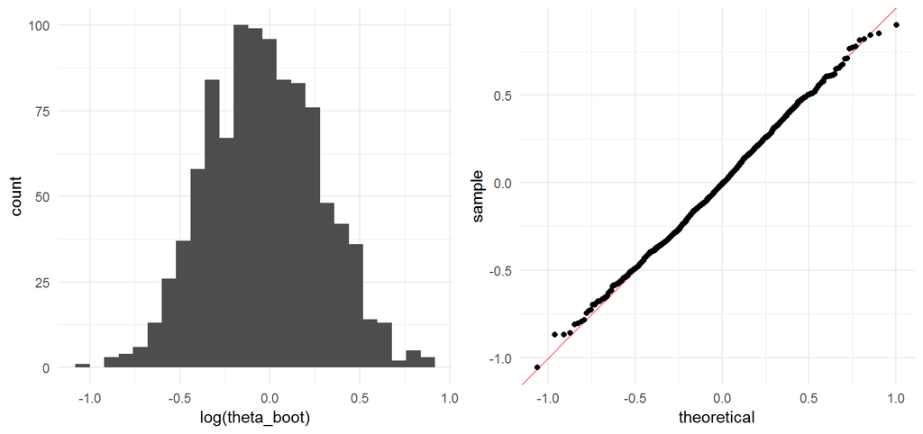

```r
hist_log <- ggplot(data_frame(theta_boot), aes(x = log(theta_boot))) +
  geom_histogram(fill = "gray30", binwidth = 0.08)
qq_log <- ggplot(data_frame(theta_boot)) +
    geom_abline(color = "red", alpha = 0.5) +
    stat_qq(aes(sample = log(theta_boot)),
        dparams = list(mean = mean(log(theta_boot)), sd = sd(log(theta_boot))))

grid.arrange(hist_log, qq_log, ncol = 2, newpage = FALSE)
```

Y los intervalos se comparan:

```r
# Normal
round(mean(x) - 1.96 * sd(log(theta_boot)), 2)
```

```
#> [1] -0.64
```

```r
round(mean(x) + 1.96 * sd(log(theta_boot)), 2)
```

```
#> [1] 0.59
```

```r
#Percentil
round(quantile(log(theta_boot), prob = 0.025), 2)
```

```
#>  2.5%
#> -0.62
```

```r
round(quantile(log(theta_boot), prob = 0.975), 2)
```

```
#> 97.5%
#>  0.58
```

La transformación logarítmica convierte la distribución de $\hat{\theta}$ en normal y por tanto los intervalos de $\hat{\phi}=log(\hat{\theta})$ son similares. La forma normal no es sorprendente pues $\hat{\phi}=\bar{x}$.

Si mapeamos los intervalos normales calculados para $log(\hat{\theta})$ de regreso a la escala de $\theta$ obtenemos intervalos similares a los calculados para $\hat{\theta}$ usando percentiles:

```r
exp(round(mean(x) - 1.96 * sd(log(theta_boot)), 2))
```

```
#> [1] 0.527
```

```r
exp(round(mean(x) + 1.96 * sd(log(theta_boot)), 2))
```

```
#> [1] 1.8
```

Podemos ver que el método de aplicar una transformación al estadístico original $\hat{\theta}$, calcular intervalos normales y aplicar la transformación inversa para volver a la escala original genera intervalos de confianza atractivos. El problema con este método es que requiere que conozcamos la transformación adecuada para cada parámetro.

Por otra parte, podemos pensar en el método del percentil como un algoritmo que incorpora la transformación de manera automática, por lo que los intervalos percentiles arrojan directamente intervalos de confianza atractivos.

**Lema.** Supongamos que la transformación $\hat{\phi}=m(\hat{\theta})$ normaliza la distribución de $\hat{\theta}$ de manera perfecta,
$$\hat{\phi} \sim N(\phi, c^2)$$
para alguna desviación estándar constante $c$. Entonces el intervalo de percentil basado en $\hat{\theta}$ es igual a
$$(m^{-1} (\hat{\phi}-z^{(1-\alpha)}c), m^{-1}(\hat{\phi}-z^{(\alpha)}c))$$

Existen otras alternativas al método del percentil y cubren otras fallas del intervalo normal. Por ejemplo, hay ocasiones en que $\hat{\theta}$ tiene una distribución normal sesgada:
$$\hat{\theta} \sim N(\theta + sesgo, se^2(\hat{\theta}))$$

en este caso no existe una transformación $m(\theta)$ que *arregle* el intervalo.

**Intervalos acelerados y corregidos por sesgo**. Esta es una versión mejorada del intervalo de percentil, la denotamos $BC_{a}$ (bias-corrected and accelerated).

**Ejemplo:** Usaremos un ejemplo de Effron y Tibshirani: los datos constan de los resultados en dos pruebas espaciales $(A, B)$ de 26 niños con algún problema neurológico. Supongamos que queremos calcular un intervalo de confianza de 90% para $\theta=var(A)$. El estimador plugin es:
$$\hat{\theta}=\sum_{i=1}^n(A_i-\bar{A})^2/n$$
notemos que el estimador *plug-in* es ligeramente menor que el estimador usual insesgado:
$$\hat{\theta}=\sum_{i=1}^n(A_i-\bar{A})^2/(n-1)$$

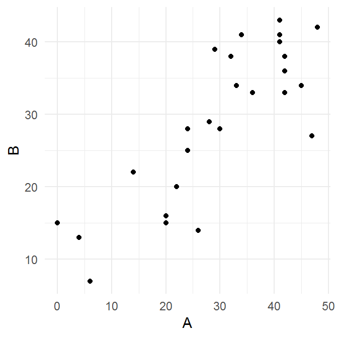

```r
library(bootstrap)
data(spatial)
ggplot(spatial) +
    geom_point(aes(A, B))
```

```r
sum((spatial$A - mean(spatial$A)) ^ 2) / nrow(spatial)
```

```
#> [1] 172
```

```r
sum((spatial$A - mean(spatial$A)) ^ 2) / (nrow(spatial) - 1)
```

```
#> [1] 178
```

El método $BC_{a}$ corrige el sesgo del estimador *plug-in* (y de cualquier otro estimador) de manera automática, lo cuál es una de sus prinicipales ventajas comparado con el método del percentil.

Los extremos en los intervalos $BC_{a}$ están dados por percentiles de la distribución bootstrap, los percentiles usados dependen de dos números $\hat{a}$ y $\hat{z}_0$, que se denominan la aceleración y la corrección del sesgo:
$$(\hat{\theta}_{\alpha}, \hat{\theta}_{1-\alpha})\approx(\hat{\theta}_B^*(\alpha_1), \hat{\theta}_B^*(\alpha_2))$$
donde
$$\alpha_1= \Phi\bigg(\hat{z}_0 + \frac{\hat{z}_0 + z^{(\alpha)}}{1- \hat{a}(\hat{z}_0 + z^{(\alpha)})}\bigg)$$
$$\alpha_2= \Phi\bigg(\hat{z}_0 + \frac{\hat{z}_0 + z^{(1-\alpha)}}{1- \hat{a}(\hat{z}_0 + z^{(1-\alpha)})}\bigg)$$
$\Phi$ es la función de distribución acumulada de la distribución normal estándar y $z^{\alpha}$ es el percentil $100 \cdot \alpha$ de una distribución normal estándar.

Notemos que si $\hat{a}$ y $\hat{z}_0$ son cero entonces $\alpha_1=\alpha$ y y $\alpha_2=1-\alpha$, obteniendo así los intervalos de percentiles.

El valor de la corrección por sesgo $\hat{z}_0$ se obtiene de la propoción de de replicaciones bootstrap menores a la estimación original $\hat{\theta}$,

$$\Phi^{-1}\bigg(\frac{\#\{\hat{\theta}^*(b) < \hat{\theta} \} }{B} \bigg)$$

a grandes razgos $\hat{z}_0$ mide la mediana del sesgo de $\hat{\theta}^*$, esto es, la discrepancia entre la mediana de $\hat{\theta}^*$ y $\hat{\theta}$ en unidades normales.

Por su parte la aceleración $\hat{a}$ se refiere a la tasa de cambio del error estándar de $\hat{\theta}$ respecto al verdadero valor del parámetro $\theta$. La aproximación normal estándar usual $\hat{\theta} \approx N(\theta, c^2)$ supone que el error estándar de $\hat{\theta}$ es el mismo para toda $\hat{\theta}$. esto puede ser poco realista, en nuestro ejemplo, donde $\hat{\theta}$ es la varianza de $A$, si los datos provienen de una normal entonces $se(\hat{\theta})$ depende de $\hat{\theta}$.

Una manera de calcular $\hat{a}$ es

$$\hat{a}=\frac{\sum_{i=1}^n (\hat{\theta}(\cdot) - \hat{\theta}(i))^3}{6\{\sum_{i=1}^n (\hat{\theta}(\cdot) - \hat{\theta}(i))^2\}^{3/2}}$$

Los intervalos $BC_{a}$ tienen 2 ventajas teóricas:

1. Respetan transformaciones: esto nos dice que los extremos del intervalo se transforman de manera adecuada si cambiamos el parámetro de interés por una función del mismo.
2. Su precisión: los intervalos $BC_{a}$ tienen precisión de segundo orden, esto es, los errores de cobertura se van a cero a una tasa de $1/n$ (los intervalos estándar y de percentiles tienen precisión de primer orden).

Los intervalos $BC_{a}$ están implementados en el paquete `boot` (`boot.ci`) y en el paquete `bootstrap` (`bcanon`).

La desventaja de los intervalos $BC_{a}$ es que requieron intenso cómputo estadístico; de acuerdo a Effron y Tibshirani al menos $B= 1000$ replicaciones son necesairas para reducir el error de muestreo. Ante esto surgen los intervalos ABC (**approximate bootstrap confidence intervals**), que es un método para aproximar $BC_{a}$ analíticamente (usando expansiones en Taylor).

Usando la implementación del paquete bootstrap:

```r
var_sesgada <- function(x) sum((x - mean(x)) ^ 2) / length(x)
bcanon(x = spatial[, 1], nboot = 2000, theta = var_sesgada)
```

```
#> $confpoints
#>      alpha bca point
#> [1,] 0.025       104
#> [2,] 0.050       115
#> [3,] 0.100       127
#> [4,] 0.160       138
#> [5,] 0.840       228
#> [6,] 0.900       243
#> [7,] 0.950       266
#> [8,] 0.975       282
#>
#> $z0
#> [1] 0.147
#>
#> $acc
#> [1] 0.0612
#>
#> $u
#>  [1] 164 177 175 178 172 172 175 172 176 173 169 168 155 142 178 178 178
#> [18] 151 178 177 166 173 177 178 178 173
#>
#> $call
#> bcanon(x = spatial[, 1], nboot = 2000, theta = var_sesgada)
```

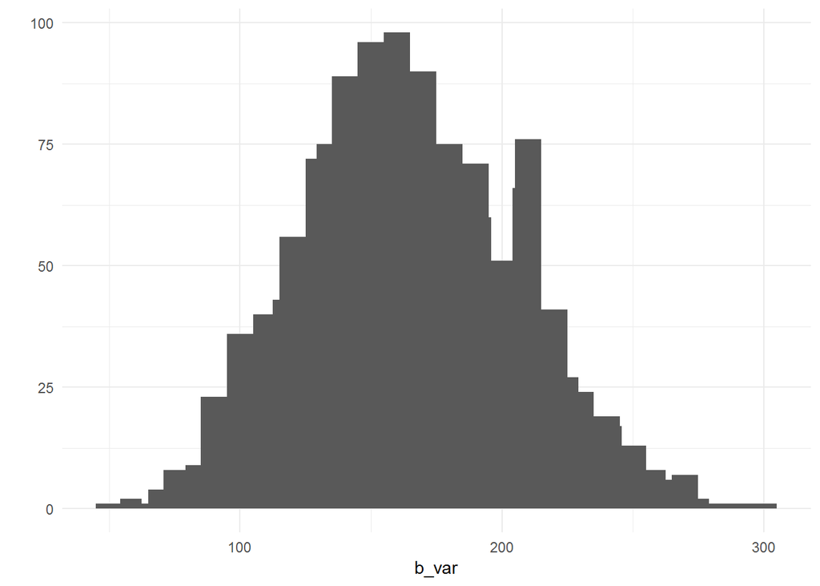

```r
b_var <- rerun(1000, var_sesgada(sample(spatial[, 1], size = length(spatial[, 1]), replace = TRUE))) %>% flatten_dbl()

qplot(b_var) + geom_histogram(binwidth = 10)
```

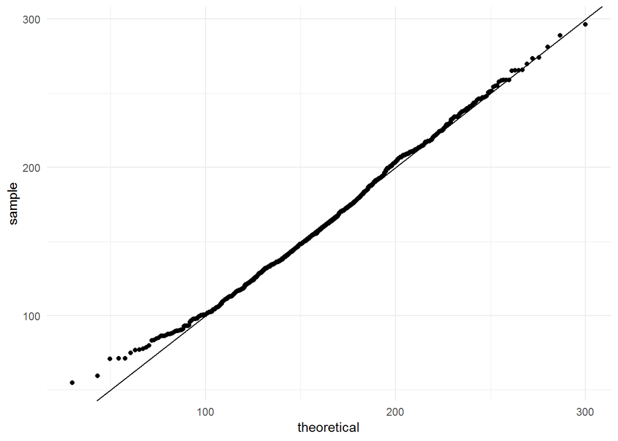

```r
ggplot(data_frame(b_var)) +
    geom_abline(color = "red", alpha = 0.5) +
    stat_qq(aes(sample = b_var),
        dparams = list(mean = mean(b_var), sd = sd(b_var))) +
  geom_abline()
```

**Ejercicio:** Comapara los intervalos del ejemplo anterior con los intervalos normales y de percentiles.

Otros intervalos basados en bootstrap incluyen los intervalos pivotales y los intervalos bootstrap-t. Sin embargo, BC y ABC son mejores alternativas.

4. **Intervalos pivotales**. Sean $\theta=t(P)$ y $\hat{\theta}=t(P_n)$. Definimos el pivote $R=\hat{\theta}-\theta$. Sea $H(r)$ la función de distribución acumulada del pivote:
   $$H(r) = P(R<r)$$

Definimos el intervalo pivotal $C_n^*=(a,b)$ donde:
$$a=\hat{\theta}-H^{-1}(1-\alpha), b=\hat{\theta}-H^{-1}(\alpha)$$
$C_n^*$ es un intervalo de confianza de $1-2\alpha$ para $\theta$; sin embargo, $a$ y $b$ dependen de la distribución desconocida $H$. Si estimamos $H(r)$ utilizando bootstrap:
$$\hat{H}(r)=\frac{1}{B}\sum_{b=1}^B I(R^*_b \le r)$$
obtenemos el estimador por intervalos:
$$\hat{C}_n^*=(2\hat{\theta} - \hat{\theta}_B^*(1-\alpha), 2\hat{\theta} + \hat{\theta}_B^*(\alpha))$$

##### Referencias

- An introduction to the bootstrap, B. Effron, R. J. Tibshirani. Tiene asociado l paquete *bootstrap* de R.
- All of statistics, L. Wasserman.
- Bootstrap Methods and their applications, A. C. Davison, D.V. Hinkley. Tiene asociado el paquete *boot* de R.
- Practical Tools for Designing and Weighting Survey Samples, R. Valliant, J.A. Dever, F. Kreuter.